# 回帰分析

モデルの評価

村田 昇

# 講義の内容

- 第1回 : 回帰モデルの考え方と推定
- **第2回 : モデルの評価**
- 第3回 : モデルによる予測と発展的なモデル

# 回帰分析の復習

## 線形回帰モデル

- **目的変数** を **説明変数** で説明する関係式を構成
  - 説明変数 : $x_{1},\dotsc,x_{p}$ (p次元)
  - 目的変数 : $y$ (1次元)
- **回帰係数** $\beta_{0},\beta_{1},\dotsc,\beta_{p}$ を用いた一次式

  $$\begin{equation}
  y=\beta_{0}+\beta_{1}x_{1}+\dotsb+\beta_{p}x_{p}
  \end{equation}$$
- **誤差項** を含む確率モデルで観測データを表現

  $$\begin{equation}
  y_i=\beta_{0}+\beta_{1} x_{i1}+\cdots+\beta_{p}x_{ip}+\epsilon_i
  \quad (i=1,\dotsc,n)
  \end{equation}$$

## 簡潔な表現のための行列

- デザイン行列 (説明変数)

  $$\begin{equation}
  X=
  \begin{pmatrix}
  1 & x_{11} & x_{12} & \cdots & x_{1p} \\
  1 & x_{21} & x_{22} & \cdots & x_{2p} \\
  \vdots & \vdots & \vdots & & \vdots \\
  1 & x_{n1} & x_{n2} & \cdots & x_{np}
  \end{pmatrix}
  \end{equation}$$

## 簡潔な表現のためのベクトル

- ベクトル (目的変数・誤差・回帰係数)

  $$\begin{equation}
  \boldsymbol{y}=
  \begin{pmatrix}
  y_{1} \\
  y_2 \\
  \vdots \\
  y_n
  \end{pmatrix},\quad
  \boldsymbol{\epsilon}=
  \begin{pmatrix}
  \epsilon_{1} \\
  \epsilon_2 \\
  \vdots \\
  \epsilon_n
  \end{pmatrix},\quad
  \boldsymbol{\beta}=
  \begin{pmatrix}
  \beta_{0} \\
  \beta_{1} \\
  \vdots \\
  \beta_{p}
  \end{pmatrix}
  \end{equation}$$

## 問題の記述

- 確率モデル

  $$\begin{equation}
  \boldsymbol{y}
  =X\boldsymbol{\beta}+\boldsymbol{\epsilon},
  \quad\boldsymbol{\epsilon}\sim\text{確率分布}
  \end{equation}$$
- 回帰式の推定 : **残差平方和** の最小化

  $$\begin{equation}
  S(\boldsymbol{\beta})
  =(\boldsymbol{y}-X\boldsymbol{\beta})^{\mathsf{T}}
  (\boldsymbol{y}-X\boldsymbol{\beta})
  \end{equation}$$

## 解の表現

- 解の条件 : **正規方程式**

  $$\begin{equation}
  X^{\mathsf{T}}X\boldsymbol{\beta}
  =X^{\mathsf{T}}\boldsymbol{y}
  \end{equation}$$
- 解の一意性 : **Gram 行列** $X^{\mathsf{T}}X$ が正則

  $$\begin{equation}
  \boldsymbol{\hat{\beta}}
  =
  (X^{\mathsf{T}}X)^{-1}
  X^{\mathsf{T}}\boldsymbol{y}
  \end{equation}$$

## 最小二乗推定量の性質

- **あてはめ値** $\boldsymbol{\hat{y}}=X\boldsymbol{\hat{\beta}}$ は $X$ の列ベクトルの線形結合
- **残差** $\boldsymbol{\hat{\epsilon}}=\boldsymbol{y}-\boldsymbol{\hat{y}}$ はあてはめ値 $\boldsymbol{\hat{y}}$ と直交

  $$\begin{equation}
  \boldsymbol{\hat{\epsilon}}^{\mathsf{T}}\boldsymbol{\hat{y}}
  =0
  \end{equation}$$
- 回帰式は説明変数と目的変数の **標本平均** を通過

  $$\begin{equation}
  \bar{y}
  =
  (1,\bar{\boldsymbol{x}}^{\mathsf{T}})\boldsymbol{\hat{\beta}},
  \quad
  \bar{\boldsymbol{x}}
  =\frac{1}{n}\sum_{i=1}^n\boldsymbol{x}_i,
  \quad
  \bar{y}
  =\frac{1}{n}\sum_{i=1}^ny_i,
  \end{equation}$$

## 寄与率

- **決定係数** (R-squared)

  $$\begin{equation}
  R^2
  =
  1-\frac{\sum_{i=1}^n\hat{\epsilon}_i^2}{\sum_{i=1}^n(y_i-\bar{y})^2}
  \end{equation}$$
- **自由度調整済み決定係数** (adjusted R-squared)

  $$\begin{equation}
  \bar{R}^2
  =
  1-\frac{\frac{1}{n{-}p{-}1}\sum_{i=1}^n\hat{\epsilon}_i^2}
  {\frac{1}{n{-}1}\sum_{i=1}^n(y_i-\bar{y})^2}
  \end{equation}$$
  - 不偏分散で補正

# 解析の事例

## 実データによる例

- 気象庁より取得した東京の気候データ
  - 気象庁 https://www.data.jma.go.jp/gmd/risk/obsdl/index.php
- 気温に影響を与える要因を分析

### データの概要

東京の8月の気候データ

| 日付 | 気温 | 降雨 | 日射 | 降雪 | 風向 | 風速 | 気圧 | 湿度 | 雲量 |
| --- | --- | --- | --- | --- | --- | --- | --- | --- | --- |
| 2025-08-01 | 26.4 | 6.0 | 9.16 | 0 | N | 3.3 | 999.0 | 83 | 10.0 |
| 2025-08-02 | 28.9 | 20.5 | 20.34 | 0 | SSE | 3.7 | 996.5 | 84 | 9.5 |
| 2025-08-03 | 30.4 | 0.0 | 21.10 | 0 | SSE | 2.6 | 1000.1 | 77 | 8.5 |
| 2025-08-04 | 31.3 | 0.0 | 26.14 | 0 | S | 4.3 | 1002.5 | 66 | 3.3 |
| 2025-08-05 | 32.1 | 0.0 | 25.58 | 0 | SSE | 3.2 | 1001.6 | 67 | 4.5 |
| 2025-08-06 | 32.3 | 0.0 | 23.20 | 0 | SSE | 2.4 | 999.8 | 68 | 7.5 |
| 2025-08-07 | 29.5 | 0.0 | 12.16 | 0 | N | 2.1 | 995.4 | 76 | 8.8 |
| 2025-08-08 | 28.6 | 3.0 | 17.46 | 0 | NW | 2.6 | 998.7 | 71 | 5.5 |
| 2025-08-09 | 28.4 | 0.0 | 18.21 | 0 | SSE | 2.7 | 1004.0 | 70 | 8.0 |
| 2025-08-10 | 26.3 | 25.5 | 4.32 | 0 | S | 4.1 | 1002.8 | 90 | 10.0 |
| 2025-08-11 | 27.1 | 11.5 | 7.97 | 0 | S | 5.6 | 1003.8 | 90 | 9.8 |
| 2025-08-12 | 28.2 | 1.0 | 6.88 | 0 | SSW | 4.4 | 1007.7 | 83 | 10.0 |
| 2025-08-13 | 27.9 | 0.0 | 17.21 | 0 | E | 2.4 | 1013.5 | 76 | 9.3 |
| 2025-08-14 | 27.8 | 0.0 | 20.39 | 0 | S | 2.6 | 1014.2 | 71 | 8.3 |
| 2025-08-15 | 28.7 | 0.0 | 24.42 | 0 | S | 2.9 | 1011.2 | 73 | 5.0 |
| 2025-08-16 | 28.8 | 1.0 | 19.08 | 0 | S | 3.1 | 1011.1 | 80 | 8.0 |
| 2025-08-17 | 29.8 | 0.0 | 22.79 | 0 | SSE | 3.2 | 1010.4 | 77 | 6.3 |
| 2025-08-18 | 31.0 | 0.0 | 22.43 | 0 | SSE | 2.5 | 1011.5 | 68 | 7.8 |
| 2025-08-19 | 29.9 | 0.0 | 22.92 | 0 | SE | 2.8 | 1009.6 | 76 | 2.0 |
| 2025-08-20 | 30.4 | 0.0 | 23.70 | 0 | SSE | 2.7 | 1007.5 | 72 | 3.5 |
| 2025-08-21 | 31.3 | 0.0 | 23.14 | 0 | SSE | 2.5 | 1007.4 | 63 | 6.5 |
| 2025-08-22 | 30.3 | 0.0 | 15.55 | 0 | SSE | 2.2 | 1007.9 | 71 | 10.0 |
| 2025-08-23 | 30.4 | 0.0 | 21.77 | 0 | SSE | 2.6 | 1007.7 | 73 | 7.3 |
| 2025-08-24 | 31.3 | 0.0 | 23.05 | 0 | NE | 2.3 | 1008.9 | 70 | 3.8 |
| 2025-08-25 | 30.6 | 0.0 | 17.21 | 0 | SSE | 2.7 | 1010.9 | 71 | 8.5 |
| 2025-08-26 | 30.1 | 0.0 | 20.41 | 0 | SSE | 3.7 | 1009.1 | 75 | 3.0 |
| 2025-08-27 | 30.7 | 0.0 | 23.07 | 0 | S | 3.6 | 1006.1 | 67 | 3.8 |
| 2025-08-28 | 28.9 | 0.0 | 15.70 | 0 | SSE | 3.0 | 1011.0 | 63 | 6.8 |
| 2025-08-29 | 28.7 | 0.0 | 18.41 | 0 | SSE | 2.4 | 1012.1 | 76 | 6.5 |
| 2025-08-30 | 31.6 | 0.0 | 23.26 | 0 | S | 2.5 | 1010.5 | 67 | 4.0 |
| 2025-08-31 | 30.9 | 0.0 | 21.83 | 0 | SE | 2.7 | 1010.3 | 73 | 1.3 |

### モデルの検討

- 気温を説明する5種類の線形回帰モデル
  - モデル1 : 気温 = F(気圧)
  - モデル2 : 気温 = F(日射)
  - モデル3 : 気温 = F(気圧, 日射)
  - モデル4 : 気温 = F(気圧, 日射, 湿度)
  - モデル5 : 気温 = F(気圧, 日射, 雲量)

### 関連するデータの散布図

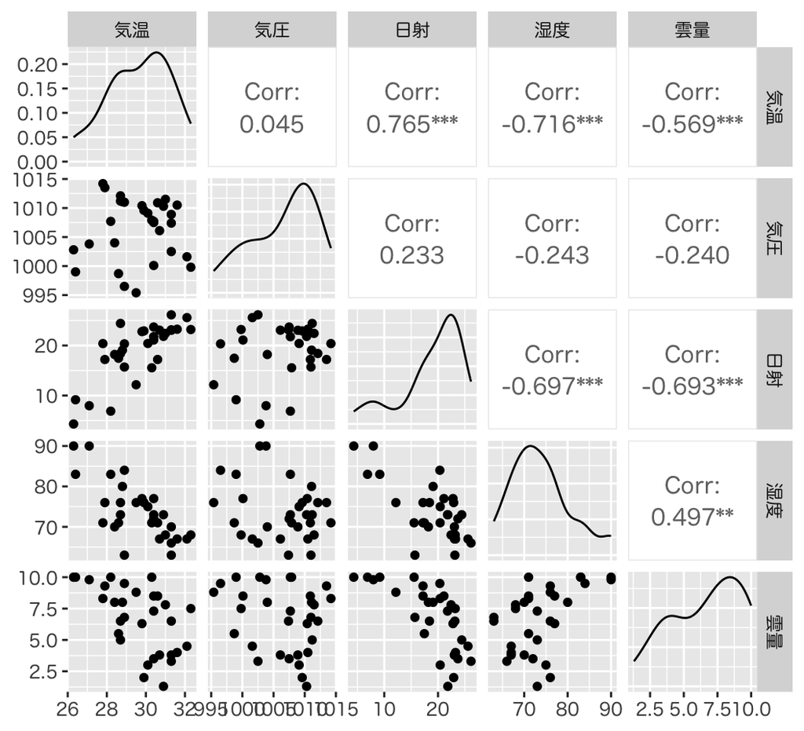

### モデル1の推定結果

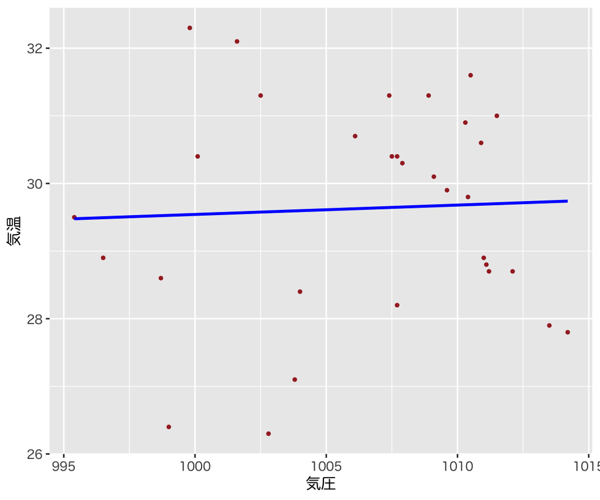

### モデル2の推定結果

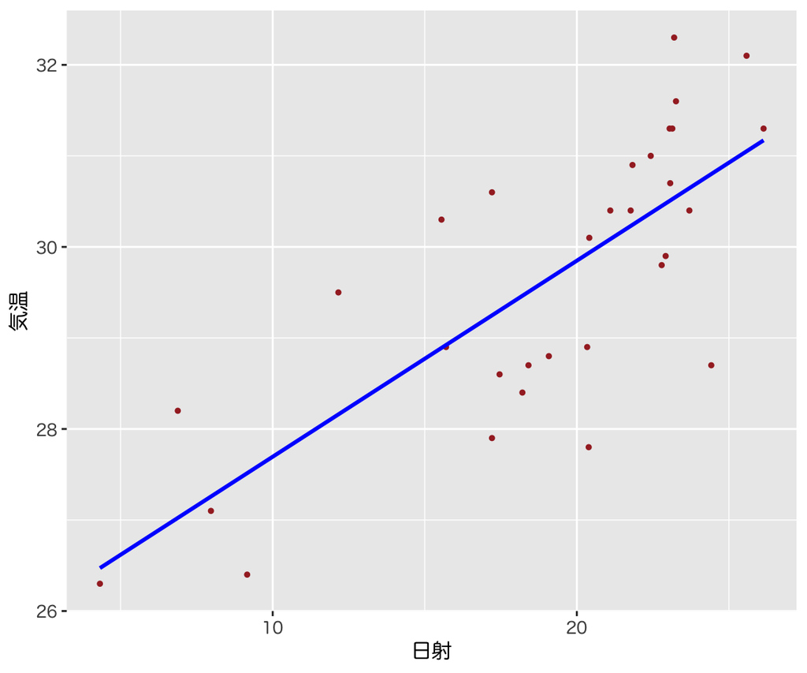

### モデル3の推定結果

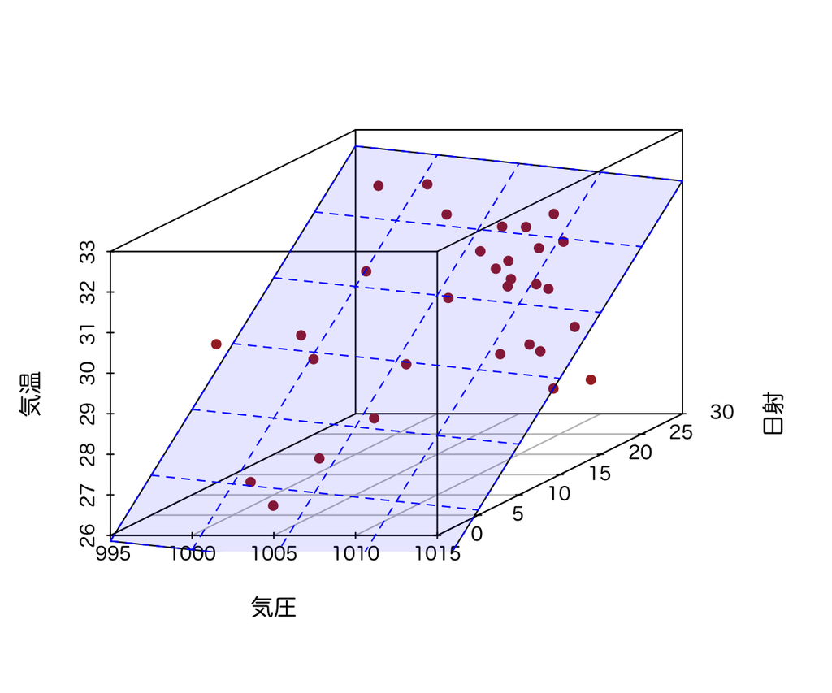

### 観測値とあてはめ値の比較

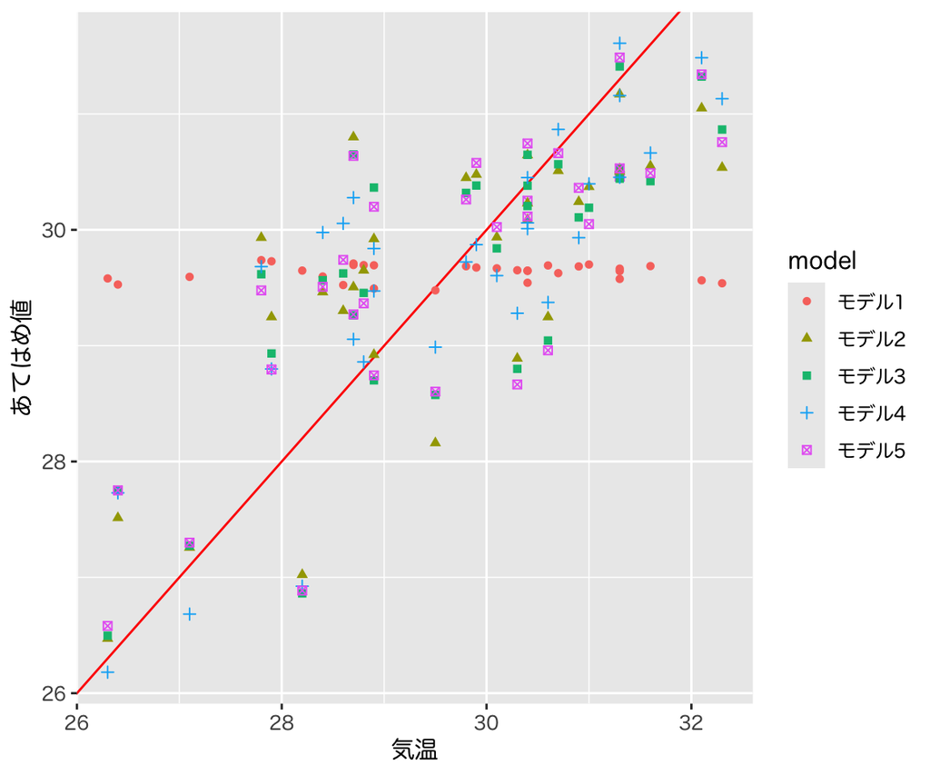

### 決定係数によるモデルの比較

| **変数** | モデル1 **係数** | モデル1 **標準誤差** | モデル2 **係数** | モデル2 **標準誤差** | モデル3 **係数** | モデル3 **標準誤差** | モデル4 **係数** | モデル4 **標準誤差** | モデル5 **係数** | モデル5 **標準誤差** |
| --- | --- | --- | --- | --- | --- | --- | --- | --- | --- | --- |
| 気圧 | 0.01 | 0.057 |  |  | -0.04 | 0.037 | -0.05 | 0.035 | -0.05 | 0.038 |
| 日射 |  |  | 0.22 | 0.034 | 0.22 | 0.034 | 0.15 | 0.043 | 0.21 | 0.047 |
| 湿度 |  |  |  |  |  |  | -0.09 | 0.035 |  |  |
| 雲量 |  |  |  |  |  |  |  |  | -0.06 | 0.102 |
| R² | 0.002 |  | 0.585 |  | 0.604 |  | 0.678 |  | 0.609 |  |
| Adjusted R² | -0.032 |  | 0.571 |  | 0.576 |  | 0.642 |  | 0.566 |  |

Abbreviations: CI = Confidence Interval, SE = Standard Error

# あてはめ値の性質

## あてはめ値

- さまざまな表現

  $$\begin{align}
  \boldsymbol{\hat{y}}
  &=X\boldsymbol{\hat{\beta}}\\
  &\qquad(\boldsymbol{\hat{\beta}}=(X^{\mathsf{T}}X)^{-1}X^{\mathsf{T}}\boldsymbol{y}を代入)\\
  &=X(X^{\mathsf{T}}X)^{-1}X^{\mathsf{T}}\boldsymbol{y}
  && (A) \\
  &\qquad(\boldsymbol{y}=X\boldsymbol{\beta}+\boldsymbol{\epsilon}を代入)\\
  &=X(X^{\mathsf{T}}X)^{-1}X^{\mathsf{T}}X\boldsymbol{\beta}
  +X(X^{\mathsf{T}}X)^{-1}X^{\mathsf{T}}\boldsymbol{\epsilon}\\
  &=X\boldsymbol{\beta}
  +X(X^{\mathsf{T}}X)^{-1}X^{\mathsf{T}}\boldsymbol{\epsilon}
  && (B) \\
  \end{align}$$
  - 1. あてはめ値は **観測値の重み付けの和** で表される
  - 2. あてはめ値と観測値は **誤差項** の寄与のみ異なる

## あてはめ値と誤差

- 残差と誤差の関係

  $$\begin{align}
  \boldsymbol{\hat{\epsilon}}
  &=\boldsymbol{y}-\boldsymbol{\hat{y}}\\
  &=\boldsymbol{\epsilon}
  -X(X^{\mathsf{T}}X)^{-1}X^{\mathsf{T}}
  \boldsymbol{\epsilon}\\
  &=\bigl(I
  -X(X^{\mathsf{T}}X)^{-1}X^{\mathsf{T}}
  \bigr)
  \boldsymbol{\epsilon}
  && (C) \\
  \end{align}$$
  - 3. 残差は **誤差の重み付けの和** で表される

## ハット行列

**ハット行列**

$$\begin{equation}
H=
X(X^{\mathsf{T}}X)^{-1}X^{\mathsf{T}}
\end{equation}$$

- ハット行列 $H$ による表現

  $$\begin{align}
  \boldsymbol{\hat{y}}
  &=H\boldsymbol{y}\\
  \boldsymbol{\hat{\epsilon}}
  &=(I-H)\boldsymbol{\epsilon}
  \end{align}$$
  - あてはめ値や残差は $H$ を用いて簡潔に表現される

## ハット行列の性質

- 観測データ(デザイン行列)のみで計算される
- 観測データと説明変数の関係を表す
- 対角成分 (**テコ比**; leverage) は観測データが自身の予測に及ぼす影響の度合を表す

  $$\begin{equation}
  \hat{y}_{j}
  =
  (H)_{jj}y_{j} + \text{(それ以外のデータの寄与)}
  \end{equation}$$
  - $(A)_{ij}$ は行列 $A$ の $(i,j)$ 成分
  - テコ比が小さい : 他のデータでも予測が可能
  - テコ比が大きい : 他のデータでは予測が困難

# 推定量の統計的性質

## 最小二乗推定量の性質

- 推定量と誤差の関係

  $$\begin{align}
  \boldsymbol{\hat{\beta}}
  &=(X^{\mathsf{T}}X)^{-1}X^{\mathsf{T}}\boldsymbol{y}\\
  &=(X^{\mathsf{T}}X)^{-1}X^{\mathsf{T}}(X\boldsymbol{\beta}+\boldsymbol{\epsilon}) \\
  &=(X^{\mathsf{T}}X)^{-1}X^{\mathsf{T}}X\boldsymbol{\beta}
  +(X^{\mathsf{T}}X)^{-1}X^{\mathsf{T}}\boldsymbol{\epsilon}\\
  &=\boldsymbol{\beta}
  +(X^{\mathsf{T}}X)^{-1}X^{\mathsf{T}}\boldsymbol{\epsilon}
  \end{align}$$
- 誤差の分布によらない最小二乗推定量の重要な性質

## 正規分布の性質

**正規分布の再生性**

正規分布に従う独立な確率変数の和は正規分布に従う

- 正規分布の重要な性質
- 誤差が正規分布に従うならば最小二乗推定量の分布が評価できる

## 推定量の分布

- **誤差の仮定** : 独立，平均0 分散 $\sigma^{2}$ の正規分布
- 推定量は以下の多変量正規分布に従う

  $$\begin{align}
  \mathbb{E}[\boldsymbol{\hat{\beta}}]
  &=\mathbb{E}[\boldsymbol{\beta}
  +(X^{\mathsf{T}}X)^{-1}X^{\mathsf{T}}\boldsymbol{\epsilon}]
  =\boldsymbol{\beta}\\
  \mathrm{Cov}(\boldsymbol{\hat{\beta}})
  &=\mathbb{E}[
  (\boldsymbol{\hat{\beta}}-\boldsymbol{\beta})
  (\boldsymbol{\hat{\beta}}-\boldsymbol{\beta})^{\mathsf{T}}]
  =\sigma^{2}(X^{\mathsf{T}}X)^{-1}
  \end{align}$$

  $$\begin{equation}
  \boldsymbol{\hat{\beta}}
  \sim
  \mathcal{N}(\boldsymbol{\beta},\sigma^{2}(X^{\mathsf{T}}X)^{-1})
  \end{equation}$$

## 分散の推定

- 通常 $\sigma^{2}$ は未知，必要な場合には不偏分散で代用

  $$\begin{equation}
  \hat{\sigma^{2}}
  =\frac{S}{n{-}p{-}1}
  =\frac{1}{n{-}p{-}1}\boldsymbol{\hat{\epsilon}}^{\mathsf{T}}\boldsymbol{\hat{\epsilon}}
  =\frac{1}{n{-}p{-}1}\sum_{i=1}^n\hat{\epsilon}_i^2
  \end{equation}$$
- これらの性質を利用してモデルの評価を行う

# 実習

# 誤差の評価

## 寄与率 (再掲)

- **決定係数** (R-squared)
  - 回帰式で説明できるばらつきの比率

  $$\begin{equation}
  R^2
  =
  1-\frac{\sum_{i=1}^n\hat{\epsilon}_i^2}{\sum_{i=1}^n(y_i-\bar{y})^2}
  \end{equation}$$
- **自由度調整済み決定係数** (adjusted R-squared)
  - 決定係数を不偏分散で補正

  $$\begin{equation}
  \bar{R}^2
  =
  1-\frac{\frac{1}{n{-}p{-}1}\sum_{i=1}^n\hat{\epsilon}_i^2}
  {\frac{1}{n{-}1}\sum_{i=1}^n(y_i-\bar{y})^2}
  \end{equation}$$

## 各係数の推定量の分布

- 推定された回帰係数の精度を評価
  - 誤差 $\epsilon$ の分布は平均0 分散 $\sigma^2$ の正規分布
  - $\boldsymbol{\hat{\beta}}$ の分布 : $p{+}1$ 変量正規分布

    $$\begin{equation}
    \boldsymbol{\hat{\beta}}
    \sim
    \mathcal{N}(\boldsymbol{\beta},\sigma^{2}(X^{\mathsf{T}}X)^{-1})
    \end{equation}$$
  - $\hat{\beta}_j$ の分布 : 1変量正規分布

    $$\begin{equation}
    \hat{\beta}_{j}
    \sim
    \mathcal{N}(\beta_{j},\sigma^{2}((X^{\mathsf{T}}X)^{-1})_{jj})
    =\mathcal{N}(\beta_{j},\sigma^{2}\zeta_{j}^{2})
    \end{equation}$$
    - $(A)_{jj}$ は行列 $A$ の $(j,j)$ (対角)成分

## 標準誤差

- **標準誤差** (standard error)
  - $\hat{\beta}_j$ の標準偏差の推定量

  $$\begin{equation}
  \mathrm{s{.}e{.}}(\hat{\beta}_{j})
  =
  \hat{\sigma}\zeta_j
  =
  \sqrt{\frac{1}{n{-}p{-}1}\sum_{i=1}^n\hat{\epsilon}_i^2}
  \cdot
  \sqrt{((X^{\mathsf{T}}X)^{-1})_{jj}}
  \end{equation}$$
  - 未知母数 $\sigma^{2}$ は不偏分散 $\hat{\sigma}^{2}$ で推定
  - $\hat{\beta}_j$ の精度の評価指標

# 実習

# 係数の評価

## $t$統計量

**回帰係数の分布に関する定理**

$t$統計量 ($t$-statistic)

$$\begin{equation}
% \text{(t統計量)}\quad
t
=
\frac{\hat{\beta}_j-\beta_j}{\mathrm{s{.}e{.}}(\hat{\beta}_{j})}
=
\frac{\hat{\beta}_j-\beta_j}{\hat{\sigma}\zeta_{j}}
\end{equation}$$

は自由度 $n{-}p{-}1$ の $t$分布に従う

- 証明には以下の性質を用いる
  - $\hat{\sigma}{}^2$ と $\boldsymbol{\hat{\beta}}$ は独立となる
  - $(\hat{\beta}_j-\beta_j)/(\sigma\zeta_j)$ は標準正規分布に従う
  - $(n{-}p{-}1)\hat{\sigma}^2/\sigma^2=S(\boldsymbol{\hat{\beta}})/\sigma^2$ は自由度 $n{-}p{-}1$ の $\chi^{2}$ 分布に従う

## $t$統計量による検定

- 回帰係数 $\beta_j$ が回帰式に寄与するか否かを検定
  - 帰無仮説 $H_{0}$ : $\beta_j=0$ ($t$統計量が計算できる)
  - 対立仮説 $H_{1}$ : $\beta_j\neq0$
- $p$値 : 確率変数の絶対値が $|t|$ を超える確率
  - $f(x)$ は自由度 $n{-}p{-}1$ の $t$分布の確率密度関数

  $$\begin{equation}
  \text{(\(p\)値)}
  =
  2\int_{|t|}^\infty f(x)dx
  \quad\text{(両側検定)}
  \end{equation}$$
- **帰無仮説 $H_{0}$ が正しければ $p$ 値は $[0,1]$ 上で一様分布する**

# 実習

# モデルの評価

## 平方和の分解(再掲)

- いろいろなばらつき
  - $S_y=(\boldsymbol{y}-\bar{\boldsymbol{y}})^{\mathsf{T}} (\boldsymbol{y}-\bar{\boldsymbol{y}})$ : 目的変数のばらつき
  - $S_{\phantom{y}}=(\boldsymbol{y}-\boldsymbol{\hat{y}})^{\mathsf{T}} (\boldsymbol{y}-\boldsymbol{\hat{y}})$ : 残差のばらつき ($\boldsymbol{\hat{\epsilon}}^{\mathsf{T}}\boldsymbol{\hat{\epsilon}}$)
  - $S_r=(\boldsymbol{\hat{y}}-\bar{\boldsymbol{y}})^{\mathsf{T}} (\boldsymbol{\hat{y}}-\bar{\boldsymbol{y}})$ : あてはめ値(回帰)のばらつき
- 3つのばらつき(平方和)の関係

  $$\begin{equation}
  (\boldsymbol{y}-\bar{\boldsymbol{y}})^{\mathsf{T}}
  (\boldsymbol{y}-\bar{\boldsymbol{y}})
  =
  (\boldsymbol{y}-\boldsymbol{\hat{y}})^{\mathsf{T}}
  (\boldsymbol{y}-\boldsymbol{\hat{y}})+
  (\boldsymbol{\hat{y}}-\bar{\boldsymbol{y}})^{\mathsf{T}}
  (\boldsymbol{\hat{y}}-\bar{\boldsymbol{y}})
  \end{equation}$$

  $$\begin{equation}
  S_y=S+S_r
  \end{equation}$$

## $F$統計量

**ばらつきの比に関する定理**

$\beta_{1}=\dotsb=\beta_{p}=0$ ならば $F$統計量 ($F$-statistic)

$$\begin{equation}
% \text{(F統計量)}\quad
F=
\frac{\frac{1}{p}S_{r}}{\frac{1}{n{-}p{-}1}S}
% =\frac{\frac{1}{p}\sum_{i=1}^n(\hat{y}_i-\bar{y})^2}
% {\frac{1}{n{-}p{-}1}\sum_{i=1}^n(y_i-\hat{y}_i)^2}
=\frac{n{-}p{-}1}{p}\frac{R^2}{1-R^2}
\end{equation}$$

は自由度 $p,n{-}p{-}1$ の $F$分布に従う

- 証明には以下の性質を用いる
  - $S_{r}$ と $S$ は独立となる
  - $S_{r}/\sigma^2$ は自由度 $p$ の $\chi^{2}$ 分布に従う
  - $S/\sigma^2$ は自由度 $n{-}p{-}1$ の $\chi^{2}$ 分布に従う

## $F$統計量を用いた検定

- 説明変数のうち1つでも役に立つか否かを検定
  - 帰無仮説 $H_{0}$ : $\beta_{1}=\dotsb=\beta_{p}=0$ ($S_r$ が $\chi^2$ 分布になる)
  - 対立仮説 $H_{1}$ : $\exists j\;\beta_j\neq0$
- $p$値 : 確率変数の値が $F$を超える確率
  - $f(x)$ は自由度 $p,n{-}p{-}1$ の $F$分布の確率密度関数

  $$\begin{equation}
  \text{(\(p\)値)}
  =
  \int_{F}^\infty f(x)dx
  \quad\text{(片側検定)}
  \end{equation}$$
- **帰無仮説 $H_{0}$ が正しければ $p$ 値は $[0,1]$ 上で一様分布する**

# 実習

# 次回の予定

- 第1回 : 回帰モデルの考え方と推定
- 第2回 : モデルの評価
- **第3回 : モデルによる予測と発展的なモデル**